# Consumer Profiles

Sajjad

5/14/2022

After completing the cleaning and exploratory data analysis in *prepareData* and *assessment* documents, here I explain the modelling steps that I took for creating customer profiles.

# Consumer Profiles

The goal of customer profiling is to categorize customers into meaningful classes. Customers in each class should share some characteristic and more importantly a specific behaviour. Our business goal is to map each customer class to a policy that help enhance business revenue.

# Variable selection using Lasso regression

This is a large dataset. I need to reduce the number of variables in the model before doing the analysis because first, having too many variables in the model will cause the analysis to lose its interpretability and second, the model can become very heavy and hard to run and handle in a reasonable time.

Here I’ve used a LASSO Regression with 10-fold cross validation to choose variables for the model. I consider variables in 3 groups, marketing information, demographic information, and time and date information. The first group of variables are coming from google analytics:

## Google Analytics Information

Here we have {campaign, Whether the customer came to the website directly, number of visits for that customer, is the customer using mobile, number of hits by customer, number of pages viewed by the customer, whether it’s a new visit or not, and the medium through which the customer accessed the online store}. The outcome ofcourse is transaction revenue.

```r
# using package glmnet for a LASSO regression with a 10-fold cross validation.
set.seed(432)
lrData <- train %>%
  select(campaign, isTrueDirect,  visitNumber, isMobile, hits,  pageviews,
         newVisits, medium, transactionRevenue)
y = lrData$transactionRevenue
x = data.matrix(lrData[,-9])

lrModel <- cv.glmnet(x, y, alpha = 1) # best lambda: lrModel$lambda.min
lrBestModel <- glmnet(x, y, alpha = 1, lambda = lrModel$lambda.min)
coef(lrBestModel)
```

```
## 9 x 1 sparse Matrix of class "dgCMatrix"
##                      s0
## (Intercept)  -1723248.0
## campaign            .
## isTrueDirect   842335.9
## visitNumber    233074.3
## isMobile     -1116448.6
## hits           823782.9
## pageviews           .
## newVisits    -1087978.3
## medium         270316.6
```

The model suggests that we don’t use campaing and pageViews variables in the analysis as it sets their coefficient to 0.

## Demographic Information

Including {region, city, and metropolitan area}.

```r
set.seed(432)
lrData <- train %>%
  select(region, city, metro, transactionRevenue)

y = lrData$transactionRevenue
x = data.matrix(lrData[,-4])

lrModel <- cv.glmnet(x, y, alpha = 1) # best lambda: lrModel$lambda.min
lrBestModel <- glmnet(x, y, alpha = 1, lambda = lrModel$lambda.min)
coef(lrBestModel)
```

[output not shown]

## Time and Date Data

{month, year, day of week, and time of visit}.

```r
set.seed(432)
lrData <- train %>%
  select(month, year, weekDay, visitTimeOfDay, transactionRevenue)

y = lrData$transactionRevenue
x = data.matrix(lrData[,-5])

lrModel <- cv.glmnet(x, y, alpha = 1) # best lambda: lrModel$lambda.min
lrBestModel <- glmnet(x, y, alpha = 1, lambda = lrModel$lambda.min)
coef(lrBestModel)
```

```
## 5 x 1 sparse Matrix of class "dgCMatrix"
##                           s0
## (Intercept)    -484820089.81
## month              -10946.95
## year               241827.99
## weekDay             48737.67
## visitTimeOfDay    -621740.99
```

# K-means clustering

I used K-means clustering to create clusters for our consumers. This is because, K-means generates exclusive sets and we want each customer to belong to exactly one group. I was also interested in comparing groups together to find groups that are close the buyers. K-means use Euclidean distances which makes comparison between groups possible. Also, the dataset has nearly 1000000 records. Therefore, run time could be problematic.

We need to prepare data for the kmeans model before running it. Below I change the type of categorical variables to numeric.

```r
kmeansData <- train %>%
  select(fullVisitorId, isTrueDirect,  visitNumber, isMobile, hits,
         newVisits, medium, transactionRevenue, visitTimeOfDay,
         transactionRevenue) %>%
  mutate(isTrueDirect = as.numeric(isTrueDirect)) %>%
  mutate(isMobile = if_else(isMobile == T, 1, 0)) %>%
  mutate(newVisits = if_else(newVisits == T, 1, 0)) %>%
  mutate(isOrganic = if_else(medium == "organic", 1, 0),
         isReferral = if_else(medium == "referral", 1, 0),
         isCPC = if_else(medium == "cpc", 1, 0),
         isAffiliate = if_else(medium == "affiliate", 1, 0),
         isCPM = if_else(medium == "cpm", 1, 0),
         isDirect = if_else(medium == "direct", 1, 0)) %>%
  mutate(isNight = if_else(visitTimeOfDay == "Night", 1, 0),
         isEvening = if_else(visitTimeOfDay == "Evening", 1, 0),
         isMorning = if_else(visitTimeOfDay == "Morning", 1, 0)) %>%
  mutate(totalRevenue = if_else(transactionRevenue == 0 |
                                  is.na(transactionRevenue), 0,
                                log(transactionRevenue))) %>%
  select(-medium, -visitTimeOfDay, -transactionRevenue)
```

I also scale and preprocess numeric values using preProcess function.

```r
preProcessed <- preProcess(kmeansData %>% select(-fullVisitorId),
                                 method = c("center", "scale"))

kmeansDataPreProcessed <- predict(preProcessed,
                                  kmeansData %>% select(-fullVisitorId))
```

Here I run K-means clustering to find 3 customer clusters.

```r
set.seed(133)
kmeansModel <- kmeans(kmeansDataPreProcessed, centers = 3, nstart = 25)
kmeansModel$centers
```

```
##   isTrueDirect visitNumber    isMobile        hits newVisits    isOrganic
## 1  -0.04490663 -0.03279434  0.03868238 -0.04756324         0  0.005526846
## 2   0.02141222  0.02234248 -0.02291278 -0.05235313         0  0.001353001
## 3   0.66516505  0.21324517 -0.39137837  3.75376242         0 -0.243945867
##     isReferral       isCPC  isAffiliate       isCPM    isDirect    isNight
## 1  0.006685882  0.01267039  0.012983875 -0.01805965 -0.02266995  0.6662647
## 2 -0.010547169 -0.01252377 -0.007732208  0.01354027  0.01749858 -0.5518521
## 3  0.200041164  0.07576038 -0.129682883  0.06718646  0.06394824 -0.3524941
##    isEvening  isMorning totalRevenue
## 1  0.6312303 -1.0928771   -0.1133488
## 2 -0.5345842  0.9150149   -0.1133488
## 3  0.1435609  0.1795573    8.4817659
```

# Customer Profiles

- The K-means model categroizes customers into 3 categories:

## Group 1 - Buyers:

They brought revenue to the company. These are less than 1.5 % of our customers who visited the store and bought something online. The K-means model points that these customer on average: * they were more likely to be *directed to the website*. * more likely to use a *desktop* computer instead of a mobile phone. * more likely to have had *previous visits* to the store. * have *more hitts* than the average. * more likley to come from a *referral* medium. * slightly more likely to come from *cost per click* or *cost per impression* channels. * more likely to shop in the *morning or evening* and less likely to shop at night.

## Group 2 - Potential Buyers:

These are the ones who wanted to buy something but didn’t buy anything. Maybe some of them changed their mind or maybe some went to the other stores. This is important for us to *keep* them on our website. Perhaps investing more in cost per click or cost per impression channels. Or maybe changing the desing of the website, especially where they spent time on, can be helpful to turn them to buyers.

## Group 3 - Window Shoppers:

The last group of customers did not buy anything from the store. I call them window shoppers. Out goal should be to direct them towards the second group. These were also the group with highest Euclidean distance from the buyers. On average: * they were *less likely to be directed* to the website. * *less* likely to use a *desktop* computer and more likely to use a mobile phone. * *less* likely to have had *previous visits* to the store. * had *fewer hits* than the average. * *more* likely to shop in the *evening* or *night*. Perhaps this last group didn’t want to buy anything but just happened to check the website. I believe these last group should be targeted by advertisement and marketing campaigns beyond our store or social media, so that we can first turn them potential buyers and then direct them towards buying something from our store.

# plot clusters

Some cleaning for plotting customer clusters.

```r
train$cluster <- kmeansModel$cluster

train <- train %>%
  mutate(cluster = case_when(
    cluster == 1 ~ "Window Shoppers",
    cluster == 2 ~ "Potential Buyers",
    cluster == 3 ~ "Buyers")) %>%
  mutate(isCA = factor(if_else(str_detect(metro, "CA") | is.na(metro), 0, 1)))
```

Here’s a graph that shows the total number of customers in each group.

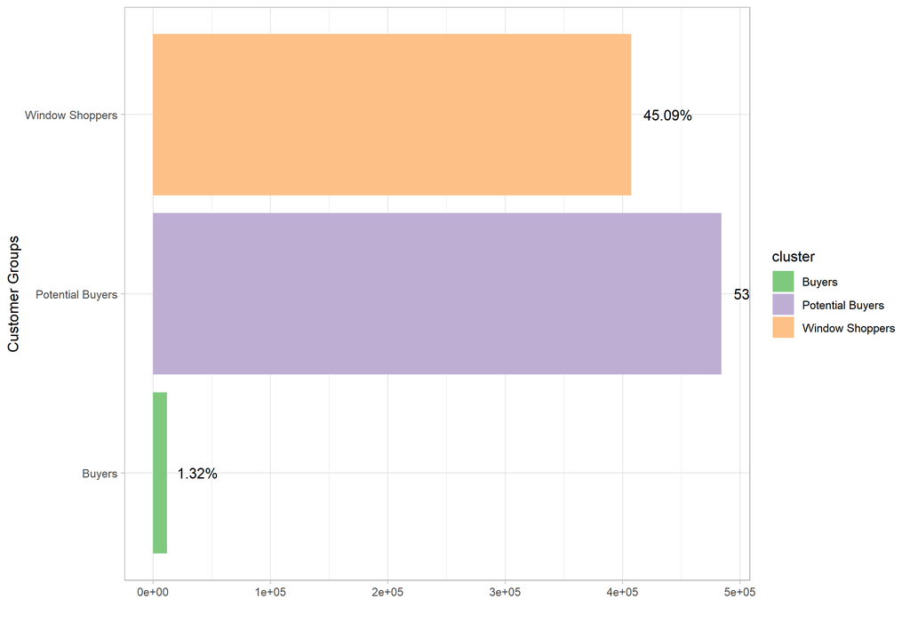

```r
train %>%
  group_by(cluster) %>%
  summarise(n=n()) %>%
  ggplot(aes(x = cluster , y = n, fill = cluster))+
  geom_bar(stat = "identity")+
  geom_text(aes(x = cluster, y = n,
                label = paste0(round(n/sum(n)*100, 2), "%")), hjust = -0.25)+
  coord_flip()+
  scale_fill_brewer(palette = "Accent")+
  labs(x = "Customer Groups", y = "")+
  theme_light()
```

```r
ggsave("customerGroupsTotal.png")
```

And here we can how each customer group varies across each medium.

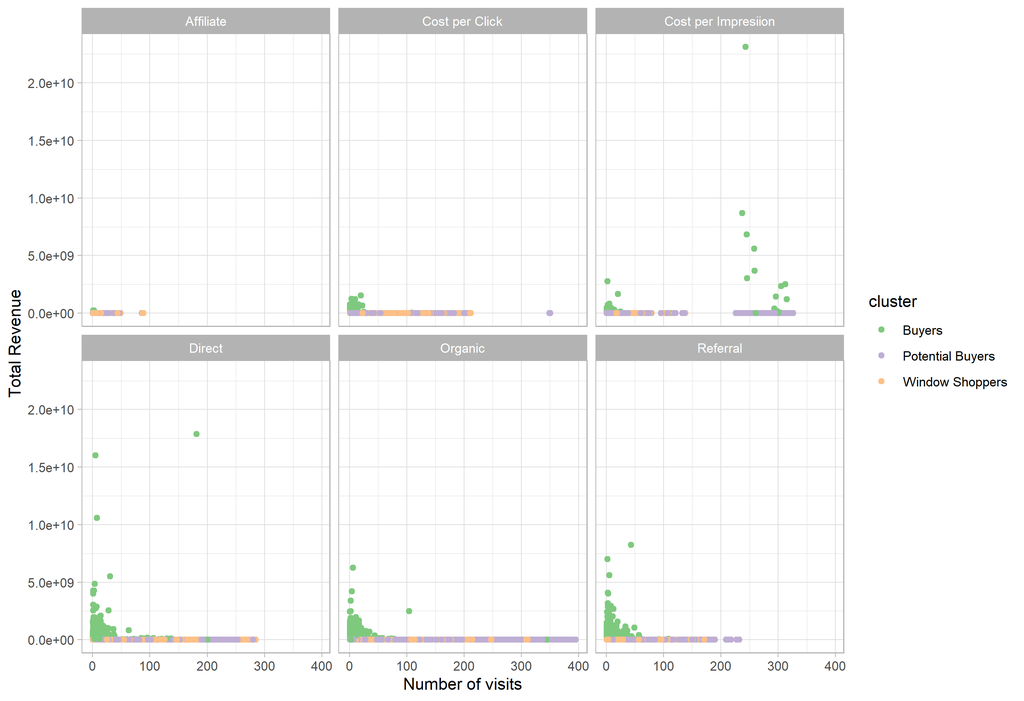

```r
train %>%
  mutate(medium = case_when(
    medium == "affiliate" ~ "Affiliate",
    medium == "cpc" ~ "Cost per Click",
    medium == "cpm" ~ "Cost per Impresiion",
    medium == "direct" ~ "Direct",
    medium == "organic" ~ "Organic",
    medium == "referral" ~ "Referral")) %>%
  ggplot(aes(x = visitNumber, y = transactionRevenue, color = cluster))+
  geom_jitter()+
  facet_wrap(~medium)+
  scale_color_brewer(palette = "Accent")+
  labs(x = "Number of visits", y = "Total Revenue")+
  theme_light()
```

```r
ggsave("customerGroupsBYMedium.png")
```